# Ford GoBike Data Analysis

## by Osama Abbas

## Investigation Overview

What do you think would affect a user's trip duration with the Ford GoBike bike sharing service? Is it the age? Their gender? Could it be the user type (one-time customer or service subscriber)? Or maybe the time of the day when they started the trip? We will try to answer all of these questions and more throughout our analysis of the Ford GoBike dataset.

## Dataset Overview

The dataset is for all trips taken during February of 2019, with 16 features recorded, including: the duration, start and end time, start and end station plus their coordinates, user birth year, user gender, etc.. and 183412 records.

# User Demographics

First, let's try to understand our users. what proportion of the users are subscribers and what proportion of them are one time customers?

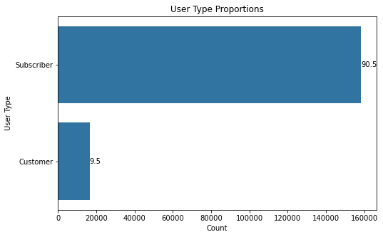

```python
plt.figure(figsize=[8,5])
base_color = sb.color_palette()[0]
sb.countplot(data = df, y ='user_type',color= base_color,order = type_order)

# iterate to annotate the proportion of each bar
for i in range (type_count.shape[0]):
    count = type_count[i]
    pct_string = '{:0.1f}'.format(100*count/n_users)

    plt.text(count+1,i, pct_string, va='center')
plt.title('User Type Proportions')
plt.ylabel('User Type')
plt.xlabel('Count');
```

We can see that 90.5% of our users for the month of February 2019 are subscribers to the service, while the remaining 9.5% are one-time customers.

# Gender Distribution

To get a better understanding of our users, we need to take a look at the proportion of the genders, as this might be an effective factor in the trip duration.

[figure not shown]

```python
plt.figure(figsize=[10,7])
# show bar chart with the proportion of each gender
sb.countplot(data = df, y = 'member_gender' ,color= base_color,order = gen_order)
# iterate to show the proportion of each gender
for i in range (gen_count.shape[0]):
    count = gen_count[i]
    pct_string = '{:0.1f}'.format(100*count/n_members)

    plt.text(count+1,i, pct_string, va='center')
plt.title('User Gender Distribution')
plt.ylabel('Gender')
plt.xlabel('Count');
```

We can see from our chart that 74.6% of our users are male, 23.3% are female, and 2.1% of the users are registered as 'other'.

# Birth Year Distribution

Now, let's take a look at the birth year of our users.

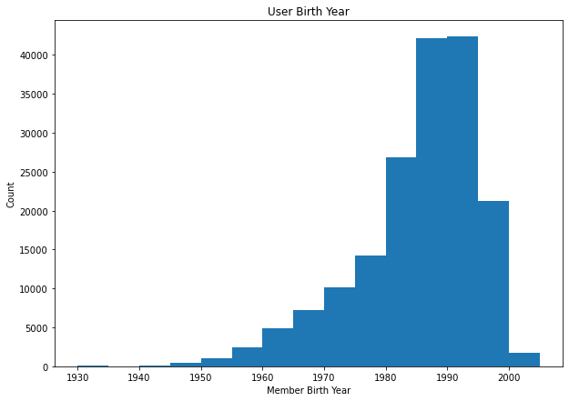

```python
plt.figure(figsize=[10,7])
# set the bins with the size of 5 years
bins = np.arange(1930, df['member_birth_year'].max()+5, 5)
# show the distribution as a histogram
plt.hist(data=df, x='member_birth_year',bins=bins);
plt.title('User Birth Year')
# set the axis labels
plt.xlabel('Member Birth Year')
plt.ylabel('Count');
```

We can see from the figure that most of our users were born between 1970 and 2000, with the peak around 1990.

# Start Hour Distribution

Another potentially effective factor is the time of the day when the trip starts. So, let's take a look at when do our users start their trips.

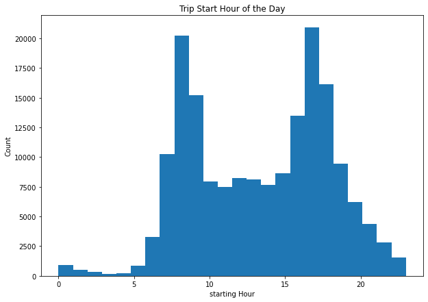

```python
plt.figure(figsize=[10,7])
# show the distribution in a histogram with a bin for each hour
plt.hist(data=df, x='start_hour',bins=24);
plt.title('Trip Start Hour of the Day')
# set the labels
plt.xlabel('starting Hour')
plt.ylabel('Count');
```

We can see from the histogram that it's a bimodal distribution with the highest counts at 8am and 5pm. This suggests that a lot of our users benefit from our service to commute from and to work.

# Trip Duration Distribution

Now, taking a glance at our main variable of interest, the duration of the trip.

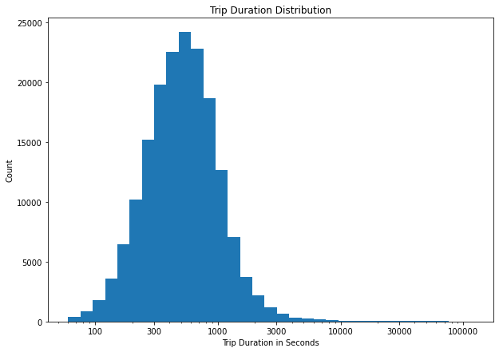

```python
plt.figure(figsize=[10,7])
# set bins according to the minimum and maximum log tranformed values
bins = 10 ** np.arange(1.78, 5+0.1, 0.1)
# set the ticks
ticks = [100, 300, 1000, 3000, 10000, 30000, 100000]
# set the ticks as strings
labels = ['{}'.format(v) for v in ticks]
# plot the duration data
plt.hist(data=df, x='duration_sec', bins=bins);
# scale the x axis to a log transformation
plt.xscale('log')
plt.title('Trip Duration Distribution')
# set the labels and ticks
plt.xlabel('Trip Duration in Seconds')
plt.ylabel('Count')
plt.xticks(ticks, labels);
```

As we can see from the histogram, the normal distribution of the duration peaks around 500 seconds with a some outliers beyond the 10000 second mark.

# Average Trip Duration by Start Hour

Up next, we will check out the effect of each of our factors on the duration. When do you think the longest trips start?

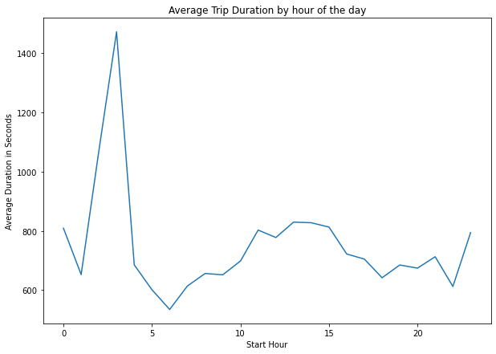

```python
plt.figure(figsize=[10,7])
color = sb.color_palette()[0]
# creat a dataframe with the start hour and duration features
start_df = df[['duration_sec','start_hour']]
# get the mean duration for each hour of the day
hour_means = start_df.groupby('start_hour').mean()
hour_means = hour_means.reset_index()
# creat a line plot to visualize the change of the mean throughout the day
plt.errorbar(data=hour_means, x='start_hour', y='duration_sec',c=color)
plt.title('Average Trip Duration by hour of the day')
# set the labels
plt.xlabel('Start Hour');
plt.ylabel('Average Duration in Seconds');
```

As shown in the line plot, the mean duration of the trip is the highest for trips that start around 3am, reaching beyond the 1400 second mark. As for the trips that start around 6am, they have the lowest mean duration.

# Average Trip Duration by Birth Year

Another question one might think of is whether, on average, younger people take longer trips then other generations? Let's find out!

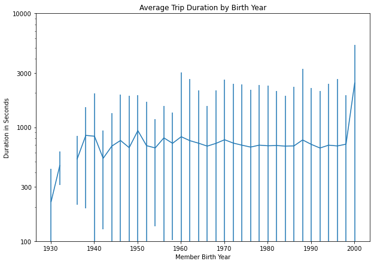

```python
plt.figure(figsize=[10,7])
dur_mean = df['duration_sec'].groupby(year_binned).mean()
dur_std = df['duration_sec'].groupby(year_binned).std()

ticks = [100, 300, 1000, 3000, 10000]

labels = ['{}'.format(v) for v in ticks]
# Plot the summarized data
plt.errorbar(x=bin_centers, y=dur_mean, yerr=dur_std)
# transform the duration to a log-type feature
plt.yscale('log')
#set ticks
plt.yticks(ticks,labels)
plt.title('Average Trip Duration by Birth Year')
# set labels
plt.ylabel('Duration in Seconds');
plt.xlabel('Member Birth Year');
```

It is noticeable from this line plot that the mean duration is the lowest for the older generations. However, the standard deviation is relatively low. On the other hand, the younger generations have higher mean duration, with the highest mean duration for the 2000 generation, however the standard deviation is the highest.

# Average Trip Duration by Gender

Another question one might ask is whether different genders have varying trip durations on average? Let's take a look.

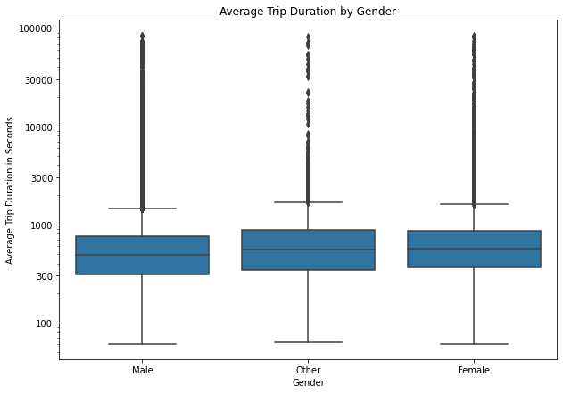

```python
plt.figure(figsize = [10, 7])
base_color = sb.color_palette()[0]

ticks = [100, 300, 1000, 3000, 10000, 30000, 100000]

labels = ['{}'.format(v) for v in ticks]

sb.boxplot(data=df, x='member_gender', y='duration_sec', color=base_color);
plt.yscale('log')
plt.yticks(ticks,labels)
plt.title('Average Trip Duration by Gender')
plt.xlabel('Gender');
plt.ylabel('Average Trip Duration in Seconds');
```

As we can see from the box plot, the median trip duration for all genders is almost identical, as well as the interquartile range. We can also see that there is a significant amount of outliers across all genders when it comes to trip duration.

# Trip Duration by User Type

Now that we saw how gender affects (or doesn't affect) the duration of the trip, do you think there might be a difference between one-time customers and subscribers in terms of duration? Let's take a look!

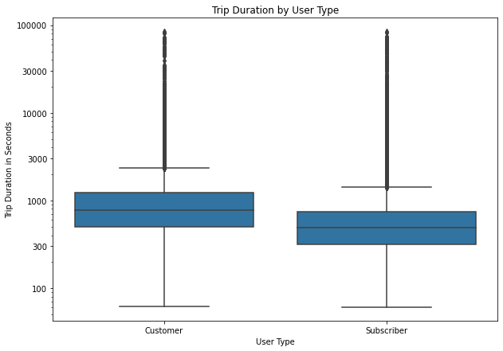

```python
plt.figure(figsize=[10,7])
sb.boxplot(data=df, x='user_type', y='duration_sec', color=base_color);
plt.yscale('log')
plt.yticks(ticks,labels)
plt.title('Trip Duration by User Type')
plt.xlabel('User Type');
plt.ylabel('Trip Duration in Seconds');
```

There is a noticeable difference in median trip duration among customer type users and subscribing users. Customers seem to have a higher median trip duration, as well as the maximum trip duration value. However, both types have a significant amount of outliers, reaching close to the 100000 second mark.

# Average Duration Across Generations by Geneder

Okay, now it is time to look a bit closer. Earlier, we understood that gender does not seem to affect the trip duration. However, do you think trip duration varies accross the genders from different generations?

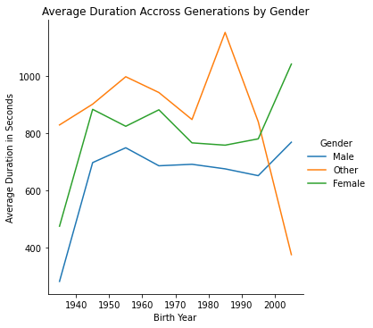

```python
bin_edges = np.arange(1930, df['member_birth_year'].max()+10, 10)
g = sb.FacetGrid(data = df, hue = 'member_gender', size = 5)

g.map(mean_poly, "member_birth_year", "duration_sec", bins = bin_edges)
plt.title('Average Duration Accross Generations by Gender')
g.set_ylabels('Average Duration in Seconds')
g.set_xlabels('Birth Year')
g.add_legend(title='Gender');
```

In the figure above we can see clearly how the 'other' gender has the highest mean durations accross different generations with a peak for the users born around 1990. However, it takes a steep drop afterwards until it reaches its lowest level for the users born in 2000 and after. On the other hand, males and females follow relatively the same trend with a rise in the mid 1940s, continuing to reach the highest mean duration after the mid 1990s. Finally, we can see a higher variance in the 'other' gender' accross generations.

# Average Duration for Trip Start Hour by Gender

Now you might be wondering whether there are different trends for each gender depending on the hour of the day when it comes to trip duration? Let's take a look!

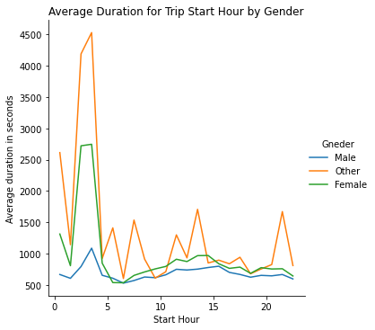

```python
# set bins for the hours
bin_edges = np.arange(0, df['start_hour'].max()+1, 1)
# creat plot instance
g = sb.FacetGrid(data = df, hue = 'member_gender', size = 5)
g.map(mean_poly, "start_hour", "duration_sec", bins = bin_edges)
plt.title('Average Duration for Trip Start Hour by Gender')
# set labels
g.set_xlabels('Start Hour')
g.set_ylabels('Average duration in seconds')
# set the legend
g.add_legend(title='Gneder');
```

From this plot we can observe how the 'other' gender has a significantly higher mean trip duration for the trips that start in the early hours of the morning, more so than other genders. We can also see higher variance across the line plot for the 'other' gender.

# Average Duration for Trip Start Hour by User Type

What about different types of users: do they have varying trends depending on the hour of the day when it comes to trip duration? Let's find out!

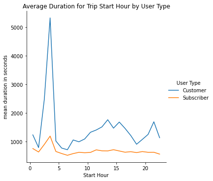

```python
# set bins for the hours
bin_edges = np.arange(0, df['start_hour'].max()+1, 1)
# creat plot instance
g = sb.FacetGrid(data = df, hue = 'user_type', size = 5)
g.map(mean_poly, "start_hour", "duration_sec", bins = bin_edges)
plt.title('Average Duration for Trip Start Hour by User Type')
# set labels
g.set_ylabels('mean duration in seconds')
g.set_xlabels('Start Hour')
# set the legend
g.add_legend(title='User Type');
```

As we can see from the line plot above, customers who had their trip start hour around 3 AM had the highest mean trip duration, reaching beyond 5000 seconds, all while having higher variance across all hours of the day. On the other hand, subscribers had lower variance and lower overall mean trip duration.

# Average Duration by User Type Across Genders

Lastly, do you think different user types from different genders have varying trends in terms of average trip duration? Let's find out!

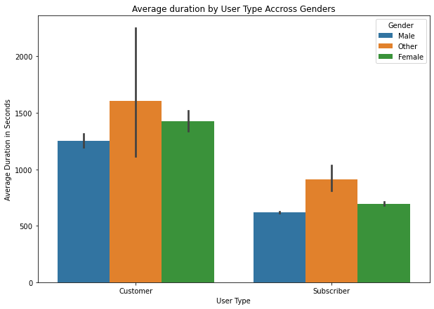

```python
# creat clustered bar plot instance
plt.figure(figsize=[10,7])
ax = sb.barplot(data = df, x = 'user_type', y = 'duration_sec', hue = 'member_gender')
#set legend
ax.legend(loc = 1, title = 'Gender');
plt.title('Average duration by User Type Accross Genders')
#set labels
plt.xlabel('User Type')
plt.ylabel('Average Duration in Seconds');
```

As we saw earlier, Customers have a higher mean trip duration, but now we can see this is true across all genders. However, when it comes to customers from the 'other' gender, they have a significantly higher standard deviation than all other categories of users.

# Conclusion

In conclusion, we now have a better understanding of each feature's effect on the duration of the bike share service trip. We came up with eye-openning insights about how different segments of users benefit from our service. For instance, we have discovered that gender does not really affect the duration of the trip, but variables such as: user type, age, and the start hour of the trip do. We also have a better understanding of users' purpose when they use our service, as most use it for workday commute. However, users who use our service for other purposes seem to have relatively higher trip durations. All of this would help us target the right customer, depending on the company objectives.